# 요인설계(Factorial Design)

각각의 완전한 시행이나 실험의 반복에서 요인수준의 모든 가능한 조합을 조사하는 것을 의미한다.

교호작용 유무:

- 교호작용이 없으면 A와 B가 상관없이 움직여서 효과에 따른 변화가 평행하다.
- 교호작용이 있으면 A와 B가 상호작용하기 때문에 효과에 따른 변화가 더 역동적으로 변한다.
  - 2요인일 경우에 주효과보다 교호작용이 매우 크면 그래프상으로 반응변수의 추이선이 교차한다.

## 회귀모형 및 반응표면

2요인 요인실험의 회귀모형

$$ y=\beta_0 + \beta_1 x_1 +\beta_2x_2 + \beta_{12} x_1 x_2 +\epsilon $$

**교호작용항을 배제한 경우**

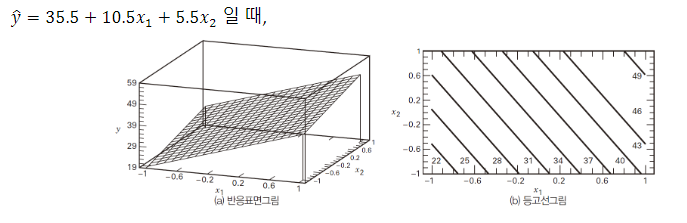

**교호작용항이 포함된 경우**

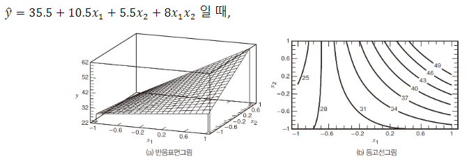

교호작용을 포함시키면 잘못된 결론 도출을 피할 수 있다.

## 2요인 요인설계

A요인의 수준이 a, B요인의 수준이 b, 관측이 n번 반복

완전 랜덤화 설계 (Completely Randomized Design)

**효과모형**

$$ y_{ijk}= \mu + \tau_i + \beta_j (\tau\beta)_{ij}+\epsilon_{ijk}\begin{cases} i=1,2,...,a\\ j=1,2,...,b\\ k=1,2,...,n \end{cases} $$

$$ \sum_{i=1}^a \tau_i = 0, \sum_{j=1}^b \beta_j = 0, \sum_{j=1}^b\sum_{i=1}^a (\tau\beta)_{ij}=0 $$

$$ H_0 : \tau_1 = \tau_2 = \cdots = \tau_a = 0 \\ H_1: \text{At least one of } \tau_i \neq 0 \text{ is true} $$

$$ H_0 : \beta_1 = \beta_2 = \cdots = \beta_b = 0 \\ H_1: \text{At least one of } \beta_i \neq 0 \text{ is true} $$

$$ H_0 : (\tau\beta)_{ij}=0\ \forall(i,j)\\ H_1: \text{At least one of } (\tau\beta)_{i,j} \neq 0 \text{ is true} $$

### Two-way ANOVA (Factorial ANOVA)

요인이 2개인 이원분산분석, 교호작용항까지 포함이 가능하다.

- 고정효과모형

$$ \overline{y}_{i..} = \frac{1}{bn} \sum_{j=1}^{b} \sum_{k=1}^{n} y_{ijk} \quad i = 1, 2, \ldots, a $$

$$ \overline{y}_{.j.} = \frac{1}{an} \sum_{i=1}^{a} \sum_{k=1}^{n} y_{ijk} \quad j = 1, 2, \ldots, b $$

$$ \sum_{i=1}^{a} \sum_{j=1}^{b} \sum_{k=1}^{n} \left( y_{ijk} - \overline{y} \right)^2 = bn \sum_{i=1}^{a} \left( \overline{y}_{i..} - \overline{y} \right)^2 + an \sum_{j=1}^{b} \left( \overline{y}_{.j.} - \overline{y} \right)^2 + \\ n \sum_{i=1}^{a} \sum_{j=1}^{b} \left( \overline{y}_{ij.} - \overline{y}_{i..} - \overline{y}_{.j.} + \overline{y} \right)^2 + \sum_{i=1}^{a} \sum_{j=1}^{b} \sum_{k=1}^{n} \left( y_{ijk} - \overline{y}_{ij.} \right)^2 $$

$$ SS_T = SS_A + SS_B + SS_{AB} + SS_E $$

$$ df \text{ breakdown:}\\ \quad abn - 1 = (a - 1) + (b - 1) + (a - 1)(b - 1) + ab(n - 1) $$

$$ SS_T = SS_A + SS_B + SS_{AB} + SS_E $$

$$ SS_T = \sum_{i=1}^{a} \sum_{j=1}^{b} \sum_{k=1}^{n} y_{ijk}^2 - \frac{y_{...}^2}{abn} $$

$$ SS_A = \frac{1}{bn} \sum_{i=1}^{a} y_{i..}^2 - \frac{y_{...}^2}{abn} $$

$$ SS_B = \frac{1}{an} \sum_{j=1}^{b} y_{.j.}^2 - \frac{y_{...}^2}{abn} $$

$$ SS_{\text{Subtotals}} = \frac{1}{n} \sum_{i=1}^{a} \sum_{j=1}^{b} y_{ij.}^2 - \frac{y_{...}^2}{abn} $$

$$ SS_{AB} = SS_{\text{Subtotals}} - SS_A - SS_B $$

$$ SS_E = SS_T - SS_{AB} - SS_A - SS_B $$

| Source of Variation | Sum of Squares | Degrees of Freedom | Mean Square | $ F_0 $ |
| --- | --- | --- | --- | --- |
| $ A $ treatments | $ SS_A $ | $ a - 1 $ | $ MS_A = \frac{SS_A}{a - 1} $ | $ F_0 = \frac{MS_A}{MS_E} $ |
| $ B $ treatments | $ SS_B $ | $ b - 1 $ | $ MS_B = \frac{SS_B}{b - 1} $ | $ F_0 = \frac{MS_B}{MS_E} $ |
| Interaction | $ SS_{AB} $ | $ (a - 1)(b - 1) $ | $ MS_{AB} = \frac{SS_{AB}}{(a - 1)(b - 1)} $ | $ F_0 = \frac{MS_{AB}}{MS_E} $ |
| Error | $ SS_E $ | $ ab(n - 1) $ | $ MS_E = \frac{SS_E}{ab(n - 1)} $ |  |
| Total | $ SS_T $ | $ abn - 1 $ |  |  |

$3^2$ 요인설계:

- 요인이 2개, 각 요인의 수준이 3개라는 의미.

```python
import numpy as np

Y = np.array([
    [
        [130, 155, 74, 180],
        [34, 40, 80, 75],
        [20, 70, 82, 58]
    ],
    [
[150, 188, 159, 126],
[136,122,106,115],
[25,70,58,45]
    ],
    [
[138,110,168,160],
[174,120,150,139],
[96,104,82,60]
    ]

])
Y
```

```
array([[[130, 155,  74, 180],
        [ 34,  40,  80,  75],
        [ 20,  70,  82,  58]],

       [[150, 188, 159, 126],
        [136, 122, 106, 115],
        [ 25,  70,  58,  45]],

       [[138, 110, 168, 160],
        [174, 120, 150, 139],
        [ 96, 104,  82,  60]]])
```

```python
Y.sum(axis=2), np.sum(Y.sum(axis=2),axis=0), np.sum(Y.sum(axis=2),axis=1)
```

```
(array([[539, 229, 230],
        [623, 479, 198],
        [576, 583, 342]]),
 array([1738, 1291,  770]),
 array([ 998, 1300, 1501]))
```

```python
SSA = 1/12 * np.sum(np.sum(Y.sum(axis=2),axis=0)**2) - np.sum(Y)**2/36
SSB = 1/12 * np.sum(np.sum(Y.sum(axis=2),axis=1)**2) - np.sum(Y)**2/36
SSsubtotal = 1/4 * np.sum(Y.sum(axis=2)**2) - np.sum(Y)**2/36
SSAB = SSsubtotal - SSA - SSB
SSE = np.sum((Y - np.mean(Y))**2) - SSA - SSB - SSAB
SSA, SSB, SSAB, SSE
```

```
(39118.72222222225, 10683.722222222248, 9613.777777777752, 18230.749999999956)
```

```python
from scipy.stats.distributions import f
import pandas as pd

MSA = SSA / 2
MSB = SSB / 2
MSAB = SSAB/4
MSE = SSE / 27

pd.DataFrame({
    '제곱합': [SSB, SSA, SSAB, SSE, np.sum((Y - np.mean(Y))**2)],
    '자유도': [2,2,4,27,35],
    '평균제곱': [MSB, MSA, MSAB, MSE, None],
    'F-통계량': [MSB/MSE, MSA/MSE, MSAB/MSE, None, None],
    '유의확률': [
                round(1 - f(2, 27).cdf(MSA/MSE),4),
                round(1 - f(2, 27).cdf(MSB/MSE),4),
                round(1 - f(4, 27).cdf(MSAB/MSE),4), None, None]
}, index=['재료 유형', '온도', '교호작용', '오차', '합계'],
dtype=np.float16)
```

|  | 제곱합 | 자유도 | 평균제곱 | F-통계량 | 유의확률 |
| --- | --- | --- | --- | --- | --- |
| 재료 유형 | 10680.0 | 2.0 | 5340.0 | 7.910156 | 0.000000 |
| 온도 | 39104.0 | 2.0 | 19552.0 | 28.968750 | 0.002001 |
| 교호작용 | 9616.0 | 4.0 | 2404.0 | 3.558594 | 0.018600 |
| 오차 | 18224.0 | 27.0 | 675.0 | NaN | NaN |
| 합계 | inf | 35.0 | NaN | NaN | NaN |

### 잔차 분석

**잔차 계산**

$$ e_{ijk} = y_{ijk} - \hat{y}_{ijk},\quad e_{ijk} = y_{ijk} - \hat{y}_{ij.} $$

```python
import pandas as pd
import matplotlib.pyplot as plt

data = {
    '재료 유형': [1] * 12 + [2] * 12 + [3] * 12,
    '온도(F)': [15] * 4 + [70] * 4 + [125] * 4 + [15] * 4 + [70] * 4 + [125] * 4 + [15] * 4 + [70] * 4 + [125] * 4,
    '잔차': [-4.75, 20.25, -23.25, -17.25, -37.50, 24.50, 12.50, 0.50, 24.00, 16.00, -6.75, -25.50,
            -5.75, 32.25, 16.25, 2.25, -24.50, 20.50, 3.25, -29.75, -13.75, -4.75, 8.50, -4.50,
            -6.00, -34.00, 28.25, -25.75, 10.50, 18.50, 8.50, 12.50, -6.75, -3.50, 25.50, -4.25]
}

df = pd.DataFrame(data)
df
```

|  | 재료 유형 | 온도(F) | 잔차 |
| --- | --- | --- | --- |
| 0 | 1 | 15 | -4.75 |
| 1 | 1 | 15 | 20.25 |
| 2 | 1 | 15 | -23.25 |
| 3 | 1 | 15 | -17.25 |
| 4 | 1 | 70 | -37.50 |
| 5 | 1 | 70 | 24.50 |
| 6 | 1 | 70 | 12.50 |
| 7 | 1 | 70 | 0.50 |
| 8 | 1 | 125 | 24.00 |
| 9 | 1 | 125 | 16.00 |
| 10 | 1 | 125 | -6.75 |
| 11 | 1 | 125 | -25.50 |
| 12 | 2 | 15 | -5.75 |
| 13 | 2 | 15 | 32.25 |
| 14 | 2 | 15 | 16.25 |
| 15 | 2 | 15 | 2.25 |
| 16 | 2 | 70 | -24.50 |
| 17 | 2 | 70 | 20.50 |
| 18 | 2 | 70 | 3.25 |
| 19 | 2 | 70 | -29.75 |
| 20 | 2 | 125 | -13.75 |
| 21 | 2 | 125 | -4.75 |
| 22 | 2 | 125 | 8.50 |
| 23 | 2 | 125 | -4.50 |
| 24 | 3 | 15 | -6.00 |
| 25 | 3 | 15 | -34.00 |
| 26 | 3 | 15 | 28.25 |
| 27 | 3 | 15 | -25.75 |
| 28 | 3 | 70 | 10.50 |
| 29 | 3 | 70 | 18.50 |
| 30 | 3 | 70 | 8.50 |
| 31 | 3 | 70 | 12.50 |
| 32 | 3 | 125 | -6.75 |
| 33 | 3 | 125 | -3.50 |
| 34 | 3 | 125 | 25.50 |
| 35 | 3 | 125 | -4.25 |

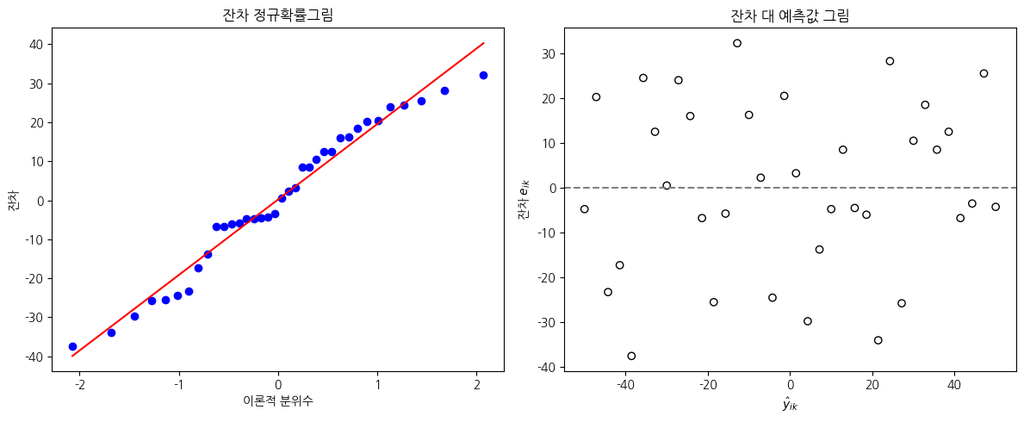

```python
import numpy as np
import matplotlib.pyplot as plt
import scipy.stats as stats

plt.rcParams['font.family'] = 'NanumGothic'
plt.rcParams['axes.unicode_minus'] = False

# 잔차 및 임의의 예측값 생성
residuals = df['잔차']
y_pred = np.linspace(-50, 50, len(residuals))  # 예측값의 임의 생성

# 1. 잔차 정규확률 그림
plt.figure(figsize=(12, 5))
plt.subplot(1, 2, 1)
stats.probplot(residuals, dist="norm", plot=plt)
plt.title('잔차 정규확률그림')
plt.xlabel('이론적 분위수')
plt.ylabel('잔차')

# 2. 잔차 대 예측값 그림
plt.subplot(1, 2, 2)
plt.scatter(y_pred, residuals, edgecolor='k', facecolor='none')
plt.axhline(y=0, color='gray', linestyle='--')
plt.title('잔차 대 예측값 그림')
plt.xlabel('$\\hat{y}_{ik}$')
plt.ylabel('잔차 $e_{ik}$')

plt.tight_layout()
plt.show()
```

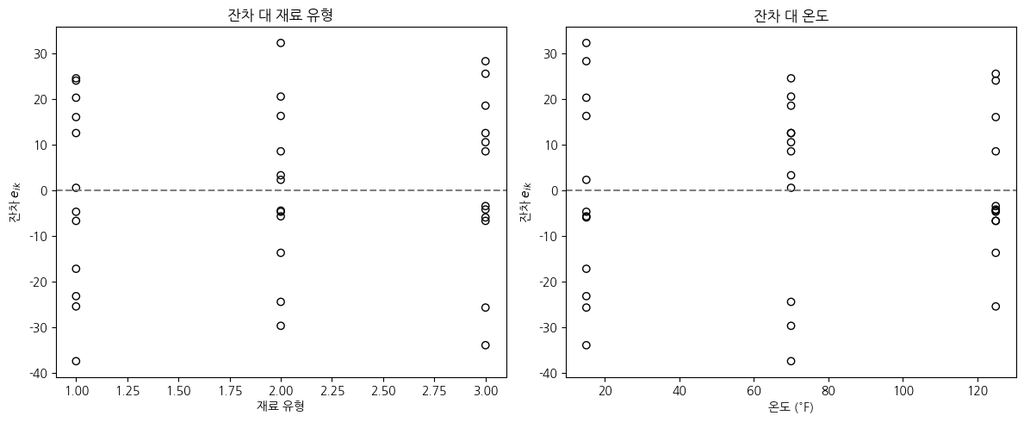

```python
import numpy as np
import matplotlib.pyplot as plt

# 데이터프레임에서 재료 유형, 온도, 잔차 추출
material_type = df['재료 유형']
temperature = df['온도(F)']
residuals = df['잔차']

# 1. 잔차 대 재료 유형 그래프
plt.figure(figsize=(12, 5))
plt.subplot(1, 2, 1)
plt.scatter(material_type, residuals, edgecolor='k', facecolor='none')
plt.axhline(y=0, color='gray', linestyle='--')
plt.title('잔차 대 재료 유형')
plt.xlabel('재료 유형')
plt.ylabel('잔차 $e_{ik}$')

# 2. 잔차 대 온도 그래프
plt.subplot(1, 2, 2)
plt.scatter(temperature, residuals, edgecolor='k', facecolor='none')
plt.axhline(y=0, color='gray', linestyle='--')
plt.title('잔차 대 온도')
plt.xlabel('온도 (°F)')
plt.ylabel('잔차 $e_{ik}$')

plt.tight_layout()
plt.show()
```

## 3요인 요인 설계 (Three-Factor Factorial Design)

**개요**: 세 개의 독립 요인을 다루며, 요인 A, B, C 각각의 주효과 및 교호작용 효과를 분석한다.

**모형 식**: $$ Y_{ijkl} = \mu + \tau_i + \beta_j + \gamma_k + (\tau\beta)_{ij} + (\tau\gamma)_{ik} + (\beta\gamma)_{jk} + \\ (\tau\beta\gamma)_{ijk} + \epsilon_{ijkl}\begin{cases} i = 1,2,...a\\ j=1,2,...,b\\ k=1,2,...,c\\ l=1,2,...,n \end{cases} $$

| 변동원인 | 제곱합 ($SS$) | 자유도 ($df$) | 평균제곱 ($MS$) | 기대평균제곱 | $F_0$ |
| --- | --- | --- | --- | --- | --- |
| A | $SS_A$ | $a - 1$ | $MS_A$ | $\sigma^2 + \frac{bcn}{a - 1} \sum \tau_i^2$ | $F_0 = \frac{MS_A}{MS_E}$ |
| B | $SS_B$ | $b - 1$ | $MS_B$ | $\sigma^2 + \frac{acn}{b - 1} \sum \beta_j^2$ | $F_0 = \frac{MS_B}{MS_E}$ |
| C | $SS_C$ | $c - 1$ | $MS_C$ | $\sigma^2 + \frac{abn}{c - 1} \sum \gamma_k^2$ | $F_0 = \frac{MS_C}{MS_E}$ |
| AB | $SS_{AB}$ | $(a - 1)(b - 1)$ | $MS_{AB}$ | $\sigma^2 + \frac{cn}{(a - 1)(b - 1)} \sum (\tau \beta)_{ij}^2$ | $F_0 = \frac{MS_{AB}}{MS_E}$ |
| AC | $SS_{AC}$ | $(a - 1)(c - 1)$ | $MS_{AC}$ | $\sigma^2 + \frac{bn}{(a - 1)(c - 1)} \sum (\tau \gamma)_{ik}^2$ | $F_0 = \frac{MS_{AC}}{MS_E}$ |
| BC | $SS_{BC}$ | $(b - 1)(c - 1)$ | $MS_{BC}$ | $\sigma^2 + \frac{an}{(b - 1)(c - 1)} \sum (\beta \gamma)_{jk}^2$ | $F_0 = \frac{MS_{BC}}{MS_E}$ |
| ABC | $SS_{ABC}$ | $(a - 1)(b - 1)(c - 1)$ | $MS_{ABC}$ | $\sigma^2 + \frac{n}{(a - 1)(b - 1)(c - 1)} \sum (\tau \beta \gamma)_{ijk}^2$ | $F_0 = \frac{MS_{ABC}}{MS_E}$ |
| 오차 | $SS_E$ | $abc(n - 1)$ | $MS_E$ | $\sigma^2$ | - |
| 합계 | $SS_T$ | $abcn - 1$ | - | - | - |

기대평균제곱: 오차에 의한 변동과 변인에 의한 변동을 이론적으로 분리한 것

$$ SS_T = \sum_{i=1}^{a} \sum_{j=1}^{b} \sum_{k=1}^{c} \sum_{l=1}^{n} y_{ijkl}^2 - \frac{y_{....}^2}{abcn} $$

$$ SS_A = \frac{1}{bcn} \sum_{i=1}^{a} y_{i\cdot\cdot\cdot}^2 - \frac{y_{....}^2}{abcn} $$

$$ SS_B = \frac{1}{acn} \sum_{j=1}^{b} y_{\cdot j\cdot\cdot}^2 - \frac{y_{....}^2}{abcn} $$

$$ SS_C = \frac{1}{abn} \sum_{k=1}^{c} y_{\cdot\cdot k\cdot}^2 - \frac{y_{....}^2}{abcn} $$

$$ SS_{AB} = \frac{1}{cn} \sum_{i=1}^{a} \sum_{j=1}^{b} y_{ij\cdot\cdot}^2 - \frac{y_{\cdot\cdot\cdot\cdot}^2}{abcn} - SS_A - SS_B =\\ SS_{\text{Subtotals}(AB)} - SS_A - SS_B $$

$$ SS_{AC} = \frac{1}{bn} \sum_{i=1}^{a} \sum_{k=1}^{c} y_{i\cdot k\cdot}^2 - \frac{y_{\cdot\cdot\cdot\cdot}^2}{abcn} - SS_A - SS_C =\\ SS_{\text{Subtotals}(AC)} - SS_A - SS_C $$

$$ SS_{BC} = \frac{1}{an} \sum_{j=1}^{b} \sum_{k=1}^{c} y_{\cdot jk\cdot}^2 - \frac{y_{\cdot\cdot\cdot\cdot}^2}{abcn} - SS_B - SS_C =\\ SS_{\text{Subtotals}(BC)} - SS_B - SS_C $$

$$ SS_{ABC} =\\ \frac{1}{n} \sum_{i=1}^{a} \sum_{j=1}^{b} \sum_{k=1}^{c} y_{ijk\cdot}^2 - \frac{y_{\cdot\cdot\cdot\cdot}^2}{abcn} - \\SS_A - SS_B - SS_C - SS_{AB} - SS_{AC} - SS_{BC} = \\SS_{\text{Subtotals}(ABC)} - SS_A - SS_B - SS_C - SS_{AB} - SS_{AC} - SS_{BC} $$

$$ SS_E = SS_T - SS_{\text{Subtotals}(ABC)} $$

```python
import numpy as np
import pandas as pd
import statsmodels.api as sm

df = pd.DataFrame({
    'ratio': [10]*8 +  [12]*8 + [14]*8,
    'pressure': ['25psd', '25psd', '30psd', '30psd'] * 6,
    'linespeed': [200, 250] * 12,
    'y': [-3, -1, -1, 1,
          -1, 0, 0, 1,
          0, 2, 2, 6,
          1, 1, 3, 5,
          5, 7, 7 ,10,
          4, 6, 9, 11]
})

df.pivot_table('y', index='ratio', columns=['pressure', 'linespeed'],
               aggfunc='sum', margins=True)
```

| pressure linespeed ratio | 25psd 200 | 25psd 250 | 30psd 200 | 30psd 250 | All |
| --- | --- | --- | --- | --- | --- |
| 10 | -4 | -1 | -1 | 2 | -4 |
| 12 | 1 | 3 | 5 | 11 | 20 |
| 14 | 9 | 13 | 16 | 21 | 59 |
| All | 6 | 15 | 20 | 34 | 75 |

```python
SST = df['y'].pow(2).sum() - df['y'].sum()**2/df['y'].count()
SSA = np.sum(df.groupby('ratio')['y'].sum().pow(2)/(2*2*2)) - df['y'].sum()**2/df['y'].count()
SSB = np.sum(df.groupby('pressure')['y'].sum().pow(2)/(3*2*2)) - df['y'].sum()**2/df['y'].count()
SSC = np.sum(df.groupby('linespeed')['y'].sum().pow(2)/(3*2*2)) - df['y'].sum()**2/df['y'].count()
SST, SSA, SSB, SSC
```

```
(336.625, 252.75, 45.375, 22.041666666666686)
```

```python
SSAB = np.sum(df.groupby(by=['ratio', 'pressure'])['y'].sum().pow(2)/(2*2)) - df['y'].sum()**2/df['y'].count() - SSA - SSB
SSAC = np.sum(df.groupby(by=['ratio', 'linespeed'])['y'].sum().pow(2)/(2*2)) - df['y'].sum()**2/df['y'].count() - SSA - SSC
SSBC = np.sum(df.groupby(by=['pressure', 'linespeed'])['y'].sum().pow(2)/(3*2)) - df['y'].sum()**2/df['y'].count() - SSB - SSC
SSAB, SSAC, SSBC
```

```
(5.25, 0.5833333333333144, 1.0416666666666288)
```

```python
SSABC = np.sum(df.groupby(by=['ratio', 'pressure','linespeed'])['y'].sum().pow(2)/(2)) - df['y'].sum()**2/df['y'].count() - SSA - SSB - SSC - SSAB - SSAC - SSBC
SSABC
```

```
1.0833333333333712
```

```python
SSE = SST - SSA - SSB - SSC - SSAB - SSAC - SSBC - SSABC
SSE
```

```
8.5
```

```python
from scipy.stats.distributions import f

pd.DataFrame({
    '변동원인': ['탄산포화비율(A)', '작용압력(B)', '라인속도(C)',
           'AB', 'AC', 'BC', 'ABC', '오차', '합계'],
    '제곱합': [SSA, SSB, SSC, SSAB, SSAC, SSBC, SSABC, SSE, SST],
    '자유도': [2, 1, 1, 2, 2, 1, 2, 12, 23],
    '평균제곱': [SSA/2, SSB, SSC, SSAB/2, SSAC/2, SSBC, SSABC/2, SSE/12, None],
    'F-통계량': [(SSA/2)/(SSE/12), (SSB/1)/(SSE/12), (SSC/1)/(SSE/12),
             (SSAB/2)/(SSE/12), (SSAC/2)/(SSE/12), (SSBC/1)/(SSE/12),
             (SSABC/2)/(SSE/12), None, None],
    '유의확률': [round(1 - f(2, 12).cdf((SSA/2)/(SSE/12)), 4),
                round(1 - f(1, 12).cdf((SSB/1)/(SSE/12)), 4),
                round(1 - f(1, 12).cdf((SSC/1)/(SSE/12)), 4),
                round(1 - f(2, 12).cdf((SSAB/2)/(SSE/12)), 4),
                round(1 - f(2, 12).cdf((SSAC/2)/(SSE/12)), 4),
                round(1 - f(1, 12).cdf((SSBC/1)/(SSE/12)), 4),
                round(1 - f(2, 12).cdf((SSABC/2)/(SSE/12)), 4), None, None]
})
```

|  | 변동원인 | 제곱합 | 자유도 | 평균제곱 | F-통계량 | 유의확률 |
| --- | --- | --- | --- | --- | --- | --- |
| 0 | 탄산포화비율(A) | 252.750000 | 2 | 126.375000 | 178.411765 | 0.0000 |
| 1 | 작용압력(B) | 45.375000 | 1 | 45.375000 | 64.058824 | 0.0000 |
| 2 | 라인속도(C) | 22.041667 | 1 | 22.041667 | 31.117647 | 0.0001 |
| 3 | AB | 5.250000 | 2 | 2.625000 | 3.705882 | 0.0558 |
| 4 | AC | 0.583333 | 2 | 0.291667 | 0.411765 | 0.6715 |
| 5 | BC | 1.041667 | 1 | 1.041667 | 1.470588 | 0.2486 |
| 6 | ABC | 1.083333 | 2 | 0.541667 | 0.764706 | 0.4869 |
| 7 | 오차 | 8.500000 | 12 | 0.708333 | NaN | NaN |
| 8 | 합계 | 336.625000 | 23 | NaN | NaN | NaN |

```python
res = sm.OLS.from_formula(formula='y ~ C(ratio) * C(pressure) * C(linespeed)', data=df).fit()
sm.stats.anova_lm(res).round(4)
```

|  | df | sum_sq | mean_sq | F | PR(>F) |
| --- | --- | --- | --- | --- | --- |
| C(ratio) | 2.0 | 252.7500 | 126.3750 | 178.4118 | 0.0000 |
| C(pressure) | 1.0 | 45.3750 | 45.3750 | 64.0588 | 0.0000 |
| C(linespeed) | 1.0 | 22.0417 | 22.0417 | 31.1176 | 0.0001 |
| C(ratio):C(pressure) | 2.0 | 5.2500 | 2.6250 | 3.7059 | 0.0558 |
| C(ratio):C(linespeed) | 2.0 | 0.5833 | 0.2917 | 0.4118 | 0.6715 |
| C(pressure):C(linespeed) | 1.0 | 1.0417 | 1.0417 | 1.4706 | 0.2486 |
| C(ratio):C(pressure):C(linespeed) | 2.0 | 1.0833 | 0.5417 | 0.7647 | 0.4869 |
| Residual | 12.0 | 8.5000 | 0.7083 | NaN | NaN |

## 2요인 랜덤화 완전블록 요인설계

$$ y_{ijk} = \mu + \tau_i + \beta_j + (\tau\beta)_{ij} + \delta_k + \epsilon_{ijk} \quad \begin{cases} i = 1, 2, \ldots, a \\ j = 1, 2, \ldots, b \\ k = 1, 2, \ldots, n \\ \end{cases} $$

| 변동원인 | 제곱합 | 자유도 | 평균제곱 | $ F_0 $ |
| --- | --- | --- | --- | --- |
| 블록 | $ \frac{1}{ab} \sum_{k=1}^n y_{..k}^2 - \frac{y_{...}^2}{abn} $ | $ n - 1 $ | $\sigma^2 + ab\sigma^2_{\delta}$ |  |
| A | $ \frac{1}{bn} \sum_{i=1}^a y_{i..}^2 - \frac{y_{...}^2}{abn} $ | $ a - 1 $ | $ MS_A $ | $ \frac{MS_A}{MS_E} $ |
| B | $ \frac{1}{an} \sum_{j=1}^b y_{.j.}^2 - \frac{y_{...}^2}{abn} $ | $ b - 1 $ | $ MS_B $ | $ \frac{MS_B}{MS_E} $ |
| AB | $ \frac{1}{n} \sum_{i=1}^a \sum_{j=1}^b y_{ij.}^2 - SS_A - SS_B - \frac{y_{...}^2}{abn} $ | $ (a-1)(b-1) $ | $ MS_{AB} $ | $ \frac{MS_{AB}}{MS_E} $ |
| 오차 | 차감 | $ (ab-1)(n-1) $ | $ MS_E $ | - |
| 합계 | $ \sum_{i=1}^a \sum_{j=1}^b \sum_{k=1}^n y_{ijk}^2 - \frac{y_{...}^2}{abn} $ | $ abn - 1 $ | - | - |

여기서:

- $ MS_A = \frac{SS_A}{a-1} $
- $ MS_B = \frac{SS_B}{b-1} $
- $ MS_{AB} = \frac{SS_{AB}}{(a-1)(b-1)} $
- $ MS_E = \frac{SS_E}{(ab-1)(n-1)} $

### 예제: 레이더 스코프 목표 탐지 능력 실험

```python
import pandas as pd
import statsmodels.api as sm
from statsmodels.formula.api import ols

# 데이터 입력
data = {
    'Filter': [1, 2] * 12,
    'Operator': [1, 1, 2, 2, 3, 3, 4, 4] * 3,
    'GroundScatter': ['Low'] * 8 + ['Medium'] * 8 + ['High'] * 8,
    'Intensity': [90, 86, 96, 84, 100, 92, 92, 81,  # 낮은 지면반사산란
                  102, 87, 106, 90, 105, 97, 96, 80,  # 중간 지면반사산란
                  114, 93, 112, 91, 108, 95, 98, 83]  # 높은 지면반사산란
}

# 데이터프레임 생성
df = pd.DataFrame(data)

# ANOVA 모델 생성
model = ols('Intensity ~ C(GroundScatter) + C(Filter) + C(GroundScatter):C(Filter) + C(Operator)', data=df).fit()
anova_table = sm.stats.anova_lm(model, typ=2)

# ANOVA 결과 출력
anova_table
```

|  | sum_sq | df | F | PR(>F) |
| --- | --- | --- | --- | --- |
| C(GroundScatter) | 335.583333 | 2.0 | 15.131513 | 2.527013e-04 |
| C(Filter) | 1066.666667 | 1.0 | 96.192385 | 6.446793e-08 |
| C(Operator) | 402.166667 | 3.0 | 12.089178 | 2.771485e-04 |
| C(GroundScatter):C(Filter) | 77.083333 | 2.0 | 3.475701 | 5.750655e-02 |
| Residual | 166.333333 | 15.0 | NaN | NaN |

## $6\times 6$ 라틴정방설계

$$ y_{ijkl} = \mu + \alpha_i + \tau_j + \beta_k + (\tau \beta)_{jk} + \theta_l + \epsilon_{ijkl} $$

$$ \begin{cases} i = 1, 2, \ldots, 6 \\ j = 1, 2, 3 \\ k = 1, 2 \\ l = 1, 2, \ldots, 6 \\ \end{cases} $$

```python
import pandas as pd

# 데이터 입력 (요인, 오퍼레이터, 필터 수준, 지면 반사 산란 수준, 결과값)
data = {
    '요일': [i for i in range(1, 7, 1) for _ in range(6) ],
    '오퍼레이터': [1, 2, 3, 4, 5, 6] * 6,
    '필터 유형 (f)':
    ['f1','f1','f1','f2','f2','f2']+
    ['f1','f1','f1','f2','f2','f2']+
    ['f1','f2','f2','f1','f2','f1']+
    ['f2','f2','f1','f1','f1','f2']+
    ['f2','f1','f2','f2','f1','f1']+
    ['f2','f2','f2','f1','f1','f1'],
    '지면 반사 산란 수준 (g)':
    ['g1', 'g2', 'g3', 'g1', 'g3', 'g2'] +
    ['g3', 'g1', 'g2', 'g3', 'g2', 'g1']+
    ['g2','g2','g3','g1','g1','g3']+
    ['g2','g1','g1','g2','g3','g3']+
    ['g3','g3','g1','g2','g1','g2']+
    ['g1','g3','g2','g3','g2','g1'],
    '결과값': [
        90, 106, 108, 81, 90, 88,  # 첫 줄
        114, 96, 105, 83, 86, 84,  # 두 번째 줄
        102, 90, 95, 92, 85, 104,  # 세 번째 줄
        87, 84, 100, 96, 110, 91,  # 네 번째 줄
        93, 112, 92, 80, 90, 98,  # 다섯 번째 줄
        86, 91, 97, 98, 100, 92   # 여섯 번째 줄
    ]
}

# 데이터프레임 생성
df = pd.DataFrame(data)
df.tail()
```

|  | 요일 | 오퍼레이터 | 필터 유형 (f) | 지면 반사 산란 수준 (g) | 결과값 |
| --- | --- | --- | --- | --- | --- |
| 31 | 6 | 2 | f2 | g3 | 91 |
| 32 | 6 | 3 | f2 | g2 | 97 |
| 33 | 6 | 4 | f1 | g3 | 98 |
| 34 | 6 | 5 | f1 | g2 | 100 |
| 35 | 6 | 6 | f1 | g1 | 92 |

```python
import statsmodels.api as sm
from statsmodels.formula.api import ols

# 열 이름의 공백을 언더스코어로 변경
df.rename(columns={'지면 반사 산란 수준 (g)': '지면_반사_산란_수준_g', '필터 유형 (f)': '필터_유형_f'}, inplace=True)

# 수정된 열 이름을 사용하여 모델 정의
model = ols(formula='결과값 ~ C(지면_반사_산란_수준_g) + C(필터_유형_f) + C(지면_반사_산란_수준_g):C(필터_유형_f) + C(요일) + C(오퍼레이터)', data=df).fit()

anova_table = sm.stats.anova_lm(model, type=2)
round(anova_table, 4)
```

|  | df | sum_sq | mean_sq | F | PR(>F) |
| --- | --- | --- | --- | --- | --- |
| C(지면_반사_산란_수준_g) | 2.0 | 571.5000 | 285.7500 | 28.8636 | 0.0000 |
| C(필터_유형_f) | 1.0 | 1469.4444 | 1469.4444 | 148.4287 | 0.0000 |
| C(요일) | 5.0 | 4.3333 | 0.8667 | 0.0875 | 0.9934 |
| C(오퍼레이터) | 5.0 | 428.0000 | 85.6000 | 8.6465 | 0.0002 |
| C(지면_반사_산란_수준_g):C(필터_유형_f) | 2.0 | 126.7222 | 63.3611 | 6.4001 | 0.0071 |
| Residual | 20.0 | 198.0000 | 9.9000 | NaN | NaN |